# Danish Kings

Marcus Fryd

2026-03-13

The task here is to load your Danish Monarchs csv into R using the `tidyverse` toolkit, calculate and explore the kings’ duration of reign with pipes `%>%` in `dplyr` and plot it over time.

## Load the kings

Make sure to first create an `.Rproj` workspace with a `data/` folder where you place either your own dataset or the provided `kings.csv` dataset.

1. Look at the dataset that are you loading and check what its columns are separated by? (hint: open it in plain text editor to see)

List what is the

separator:semicolon

2. Create a `kings` object in R with the different functions below and inspect the different outputs.
- `read.csv()`
- `read_csv()`
- `read.csv2()`
- `read_csv2()`

```r
# FILL IN THE CODE BELOW and review the outputs
library(tidyverse)
kings1 <- read.csv("data/Kongeraekke(Ark1).csv")

kings2 <- read_csv("data/Kongeraekke(Ark1).csv")
kings3 <- read.csv2("data/Kongeraekke(Ark1).csv")

kings4 <- read_csv2( "data/Kongeraekke(Ark1).csv")
```

```
## ℹ Using "','" as decimal and "'.'" as grouping mark. Use `read_delim()` for more control.
```

```r
kings1
```

```
##                 keyid.monarchs.birth.death.reign_start.reign_end.notes
## 1     0;gorm_den_gamle;NA;958;936;958;reign_start_mentioned_first_here
## 2                       1;harald_blaatand;NA;987;958;987;birth_unknown
## 3                      2;svend_tveskaeg;NA;1014;987;1014;birth_unknown
## 4                          3;harald_ii;NA;1018;1014;1018;birth_unknown
## 5                               4;knud_i_den_store;995;1035;1018;1035;
## 6                                     5;hardeknud;1020;1042;1035;1042;
## 7                               6;magnus_den_gode;1024;1047;1042;1047;
## 8                 7;svend_ii_estridsen;NA;1074;1047;1074;birth_unknown
## 9                     8;harald_iIi_hen;NA;1080;1074;1080;birth_unknown
## 10               9;knud_ii_den_hellige;NA;1086;1080;1086;birth_unknown
## 11                    10;oluf_i_hunger;NA;1095;1086;1095;birth_unknown
## 12                               11;erik_i_ejegod;1056;1103;1095;1103;
## 13                            12;niels;NA;1134;1104;1134;birth_unknown
## 14                    13;erik_ii_emune;NA;1137;1134;1137;birth_unknown
```

[output cut: 39 more lines]

```r
glimpse(kings1)
```

```
## Rows: 53
## Columns: 1
## $ keyid.monarchs.birth.death.reign_start.reign_end.notes <chr> "0;gorm_den_gam…
```

```r
class(kings1)
```

```
## [1] "data.frame"
```

```r
kings2
```

```
## # A tibble: 53 × 1
##    `keyid;monarchs;birth;death;reign_start;reign_end;notes`
##    <chr>
##  1 0;gorm_den_gamle;NA;958;936;958;reign_start_mentioned_first_here
##  2 1;harald_blaatand;NA;987;958;987;birth_unknown
##  3 2;svend_tveskaeg;NA;1014;987;1014;birth_unknown
##  4 3;harald_ii;NA;1018;1014;1018;birth_unknown
##  5 4;knud_i_den_store;995;1035;1018;1035;
##  6 5;hardeknud;1020;1042;1035;1042;
##  7 6;magnus_den_gode;1024;1047;1042;1047;
##  8 7;svend_ii_estridsen;NA;1074;1047;1074;birth_unknown
##  9 8;harald_iIi_hen;NA;1080;1074;1080;birth_unknown
## 10 9;knud_ii_den_hellige;NA;1086;1080;1086;birth_unknown
## # ℹ 43 more rows
```

```r
glimpse(kings2)
```

```
## Rows: 53
## Columns: 1
## $ `keyid;monarchs;birth;death;reign_start;reign_end;notes` <chr> "0;gorm_den_g…
```

```r
class(kings2)
```

```
## [1] "spec_tbl_df" "tbl_df"      "tbl"         "data.frame"
```

```r
kings3
```

```
##    keyid               monarchs birth death reign_start reign_end
## 1      0         gorm_den_gamle    NA   958         936       958
## 2      1        harald_blaatand    NA   987         958       987
## 3      2         svend_tveskaeg    NA  1014         987      1014
## 4      3              harald_ii    NA  1018        1014      1018
## 5      4       knud_i_den_store   995  1035        1018      1035
## 6      5              hardeknud  1020  1042        1035      1042
## 7      6        magnus_den_gode  1024  1047        1042      1047
## 8      7     svend_ii_estridsen    NA  1074        1047      1074
## 9      8         harald_iIi_hen    NA  1080        1074      1080
## 10     9    knud_ii_den_hellige    NA  1086        1080      1086
## 11    10          oluf_i_hunger    NA  1095        1086      1095
## 12    11          erik_i_ejegod  1056  1103        1095      1103
## 13    12                  niels    NA  1134        1104      1134
## 14    13          erik_ii_emune    NA  1137        1134      1137
## 15    14           erik_iii_lam    NA  1146        1137      1146
## 16    15       valdemar_i_store  1131  1182        1146      1182
## 17    16                knud_iv  1163  1202        1182      1202
## 18    17       valdemar_ii_sejr  1170  1241        1202      1241
## 19    18    erik_iv_plovpenning  1216  1250        1241      1250
## 20    19                   abel  1218  1252        1250      1252
## 21    20          christoffer_i  1219  1259        1252      1259
## 22    21        erik_v_klipping  1249  1286        1259      1286
## 23    22         erik_vi_menved  1274  1319        1286      1319
## 24    23         christoffer_ii  1276  1332        1319      1326
## 25    24           valdemar_iii  1315  1364        1326      1329
## 26    23   christoffer_ii_again  1276  1332        1329      1332
## 27    25   valdemar_iv_atterdag  1320  1375        1340      1375
## 28    27                oluf_ii  1370  1387        1375      1387
## 29    26             margrete_i  1353  1412        1387      1396
## 30    28       erik_vii_pommern  1382  1459        1396      1439
## 31    29 christoffer_iii_bayern  1416  1448        1440      1448
## 32    30            christian_i  1426  1481        1448      1481
## 33    31                   hans  1455  1513        1482      1513
## 34    33           christian_ii  1481  1559        1513      1523
## 35    32             frederik_i  1471  1533        1523      1533
## 36    34          christian_iii  1503  1559        1536      1559
## 37    35            frederik_ii  1534  1588        1559      1588
## 38    36           christian_iv  1577  1648        1596      1648
## 39    37           frederik_iii  1609  1670        1648      1670
```

[output cut: 53 more lines]

```
## 39
## 40
## 41
## 42
## 43
## 44
## 45
## 46
## 47
## 48
## 49
## 50
## 51
## 52                      still_alive
## 53                      still_alive
```

```r
glimpse(kings3)
```

```
## Rows: 53
## Columns: 7
## $ keyid       <int> 0, 1, 2, 3, 4, 5, 6, 7, 8, 9, 10, 11, 12, 13, 14, 15, 16, …
## $ monarchs    <chr> "gorm_den_gamle", "harald_blaatand", "svend_tveskaeg", "ha…
## $ birth       <int> NA, NA, NA, NA, 995, 1020, 1024, NA, NA, NA, NA, 1056, NA,…
## $ death       <int> 958, 987, 1014, 1018, 1035, 1042, 1047, 1074, 1080, 1086, …
## $ reign_start <int> 936, 958, 987, 1014, 1018, 1035, 1042, 1047, 1074, 1080, 1…
## $ reign_end   <int> 958, 987, 1014, 1018, 1035, 1042, 1047, 1074, 1080, 1086, …
## $ notes       <chr> "reign_start_mentioned_first_here", "birth_unknown", "birt…
```

```r
class(kings3)
```

```
## [1] "data.frame"
```

```r
kings4
```

```
## # A tibble: 53 × 7
##    keyid monarchs            birth death reign_start reign_end notes
##    <dbl> <chr>               <dbl> <dbl>       <dbl>     <dbl> <chr>
##  1     0 gorm_den_gamle         NA   958         936       958 reign_start_ment…
##  2     1 harald_blaatand        NA   987         958       987 birth_unknown
##  3     2 svend_tveskaeg         NA  1014         987      1014 birth_unknown
##  4     3 harald_ii              NA  1018        1014      1018 birth_unknown
##  5     4 knud_i_den_store      995  1035        1018      1035 <NA>
##  6     5 hardeknud            1020  1042        1035      1042 <NA>
##  7     6 magnus_den_gode      1024  1047        1042      1047 <NA>
##  8     7 svend_ii_estridsen     NA  1074        1047      1074 birth_unknown
##  9     8 harald_iIi_hen         NA  1080        1074      1080 birth_unknown
## 10     9 knud_ii_den_hellige    NA  1086        1080      1086 birth_unknown
## # ℹ 43 more rows
```

```r
glimpse(kings4)
```

```
## Rows: 53
## Columns: 7
## $ keyid       <dbl> 0, 1, 2, 3, 4, 5, 6, 7, 8, 9, 10, 11, 12, 13, 14, 15, 16, …
## $ monarchs    <chr> "gorm_den_gamle", "harald_blaatand", "svend_tveskaeg", "ha…
## $ birth       <dbl> NA, NA, NA, NA, 995, 1020, 1024, NA, NA, NA, NA, 1056, NA,…
## $ death       <dbl> 958, 987, 1014, 1018, 1035, 1042, 1047, 1074, 1080, 1086, …
## $ reign_start <dbl> 936, 958, 987, 1014, 1018, 1035, 1042, 1047, 1074, 1080, 1…
## $ reign_end   <dbl> 958, 987, 1014, 1018, 1035, 1042, 1047, 1074, 1080, 1086, …
## $ notes       <chr> "reign_start_mentioned_first_here", "birth_unknown", "birt…
```

```r
class(kings4)
```

```
## [1] "spec_tbl_df" "tbl_df"      "tbl"         "data.frame"
```

Answer: 1. Which of these functions is a `tidyverse` function? Read data with it below into a `kings` object

The ones with underscore “_” and not a period. For that reason, the read_csv2() function is the better option in my case.

2. What is the result of running `class()` on the `kings` object created with a tidyverse function.

[1] “spec_tbl_df” “tbl_df” “tbl” “data.frame”

3. How many columns does the object have when created with these different functions?

For the “csv” functions, there is only one column. For “csv2” functions, there are 7.

4. Show the dataset so that we can see how R interprets each column

We can use the glimpse() function to view each column and its datatype.

```r
# COMPLETE THE BLANKS BELOW WITH YOUR CODE, then turn the 'eval' flag in this chunk to TRUE.
library(tidyverse)
kings <- read_csv2("data/Kongeraekke(Ark1).csv")
```

```
## ℹ Using "','" as decimal and "'.'" as grouping mark. Use `read_delim()` for more control.
```

```r
class(kings)
```

```
## [1] "spec_tbl_df" "tbl_df"      "tbl"         "data.frame"
```

```r
glimpse(kings)
```

```
## Rows: 53
## Columns: 7
## $ keyid       <dbl> 0, 1, 2, 3, 4, 5, 6, 7, 8, 9, 10, 11, 12, 13, 14, 15, 16, …
## $ monarchs    <chr> "gorm_den_gamle", "harald_blaatand", "svend_tveskaeg", "ha…
## $ birth       <dbl> NA, NA, NA, NA, 995, 1020, 1024, NA, NA, NA, NA, 1056, NA,…
## $ death       <dbl> 958, 987, 1014, 1018, 1035, 1042, 1047, 1074, 1080, 1086, …
## $ reign_start <dbl> 936, 958, 987, 1014, 1018, 1035, 1042, 1047, 1074, 1080, 1…
## $ reign_end   <dbl> 958, 987, 1014, 1018, 1035, 1042, 1047, 1074, 1080, 1086, …
## $ notes       <chr> "reign_start_mentioned_first_here", "birth_unknown", "birt…
```

```r
head(kings)
```

```
## # A tibble: 6 × 7
##   keyid monarchs         birth death reign_start reign_end notes
##   <dbl> <chr>            <dbl> <dbl>       <dbl>     <dbl> <chr>
## 1     0 gorm_den_gamle      NA   958         936       958 reign_start_mentione…
## 2     1 harald_blaatand     NA   987         958       987 birth_unknown
## 3     2 svend_tveskaeg      NA  1014         987      1014 birth_unknown
## 4     3 harald_ii           NA  1018        1014      1018 birth_unknown
## 5     4 knud_i_den_store   995  1035        1018      1035 <NA>
## 6     5 hardeknud         1020  1042        1035      1042 <NA>
```

## Calculate the duration of reign for all the kings in your table

You can calculate the duration of reign in years with `mutate` function by subtracting the equivalents of your `startReign` from `endReign` columns and writing the result to a new column called `duration`. But first you need to check a few things:

- Is your data messy? Fix it before re-importing to R
- Do your start and end of reign columns contain NAs? Choose the right strategy to deal with them: `na.omit()`, `na.rm=TRUE`, `!is.na()`

Create a new column called `duration` in the kings dataset, utilizing the `mutate()` function from tidyverse. Check with your group to brainstorm the options.

```r
# YOUR CODE
library(tidyverse)
kings %>%
  filter(!is.na(reign_end)) %>%
  filter(!is.na(reign_start)) %>%
   mutate(duration=reign_end-reign_start)
```

```
## # A tibble: 52 × 8
##    keyid monarchs            birth death reign_start reign_end notes    duration
##    <dbl> <chr>               <dbl> <dbl>       <dbl>     <dbl> <chr>       <dbl>
##  1     0 gorm_den_gamle         NA   958         936       958 reign_s…       22
##  2     1 harald_blaatand        NA   987         958       987 birth_u…       29
##  3     2 svend_tveskaeg         NA  1014         987      1014 birth_u…       27
##  4     3 harald_ii              NA  1018        1014      1018 birth_u…        4
##  5     4 knud_i_den_store      995  1035        1018      1035 <NA>           17
##  6     5 hardeknud            1020  1042        1035      1042 <NA>            7
##  7     6 magnus_den_gode      1024  1047        1042      1047 <NA>            5
##  8     7 svend_ii_estridsen     NA  1074        1047      1074 birth_u…       27
##  9     8 harald_iIi_hen         NA  1080        1074      1080 birth_u…        6
## 10     9 knud_ii_den_hellige    NA  1086        1080      1086 birth_u…        6
## # ℹ 42 more rows
```

## Calculate the average duration of reign for all rulers

Do you remember how to calculate an average on a vector object? If not, review the last two lessons and remember that a column is basically a vector. So you need to subset your `kings` dataset to the `duration` column. If you subset it as a vector you can calculate average on it with `mean()` base-R function. If you subset it as a tibble, you can calculate average on it with `summarize()` tidyverse function. Try both ways!

- You first need to know how to select the relevant `duration` column. What are your options?
- Is your selected `duration` column a tibble or a vector? The `mean()` function can only be run on a vector. The `summarize()` function works on a tibble.
- Are you getting an error that there are characters in your column? Coerce your data to numbers with `as.numeric()`.
- Remember to handle NAs: `mean(X, na.rm=TRUE)`

```r
# YOUR CODE
library(tidyverse)
# We try firstly using R's "mean()" function
kings_with_duration <- kings %>%
  filter(!is.na(reign_end)) %>%
  filter(!is.na(reign_start)) %>%
   mutate(reign_duration=reign_end-reign_start)
reign_duration <- kings_with_duration$reign_duration
mean(reign_duration)
```

```
## [1] 20.5
```

```r
# We now try using the "summarise()" function of tidyverse
kings %>%
  filter(!is.na(reign_end)) %>%
  filter(!is.na(reign_start)) %>%
  mutate(reign_duration=reign_end-reign_start) %>%
  summarise(mean_duration=mean(reign_duration))
```

```
## # A tibble: 1 × 1
##   mean_duration
##           <dbl>
## 1          20.5
```

```r
# Both ways give us a mean of 20,5
```

## How many and which kings enjoyed a longer-than-average duration of reign?

You have calculated the average duration above. Use it now to `filter()` the `duration` column in `kings` dataset. Display the result and also count the resulting rows with `count()`

```r
# YOUR CODE
library(tidyverse)
kings_long_reign <- kings_with_duration %>%
  select(monarchs,reign_duration) %>%
  filter(reign_duration>20.5)
kings_long_reign
```

```
## # A tibble: 25 × 2
##    monarchs             reign_duration
##    <chr>                         <dbl>
##  1 gorm_den_gamle                   22
##  2 harald_blaatand                  29
##  3 svend_tveskaeg                   27
##  4 svend_ii_estridsen               27
##  5 niels                            30
##  6 valdemar_i_store                 36
##  7 valdemar_ii_sejr                 39
##  8 erik_v_klipping                  27
##  9 erik_vi_menved                   33
## 10 valdemar_iv_atterdag             35
## # ℹ 15 more rows
```

```r
count(kings_long_reign)
```

```
## # A tibble: 1 × 1
##       n
##   <int>
## 1    25
```

```r
# By using count(), we see that there were 25 monarchs that had a longer than average duration of reign.
```

## How many days did the three longest-ruling monarchs rule?

- Sort kings by reign `duration` in the descending order. Select the three longest-ruling monarchs with the `slice()` function
- Use `mutate()` to create `Days` column where you calculate the total number of days they ruled
- BONUS: consider the transition year (with 366 days) in your calculation!

```r
# YOUR CODE
kings_with_duration %>%
  arrange(desc(reign_duration)) %>%
  slice(1:3) %>%
  mutate(duration_days=reign_duration*365.25) %>%
  select(monarchs,reign_start,reign_end,reign_duration,duration_days)
```

```
## # A tibble: 3 × 5
##   monarchs         reign_start reign_end reign_duration duration_days
##   <chr>                  <dbl>     <dbl>          <dbl>         <dbl>
## 1 christian_iv            1596      1648             52        18993
## 2 margrethe_ii            1972      2024             52        18993
## 3 erik_vii_pommern        1396      1439             43        15706.
```

## Challenge: Plot the kings’ duration of reign through time

What is the long-term trend in the duration of reign among Danish monarchs? How does it relate to the historical violence trends ?

- Try to plot the duration of reign column in `ggplot` with `geom_point()` and `geom_smooth()`
- In order to peg the duration (which is between 1-99) somewhere to the x axis with individual centuries, I recommend creating a new column `midyear` by adding to `startYear` the product of `endYear` minus the `startYear` divided by two (`startYear + (endYear-startYear)/2`).
- Now you can plot the kings dataset, plotting `midyear` along the x axis and `duration` along y axis
- BONUS: add a title, nice axis labels to the plot and make the theme B&W and font bigger to make it nice and legible!

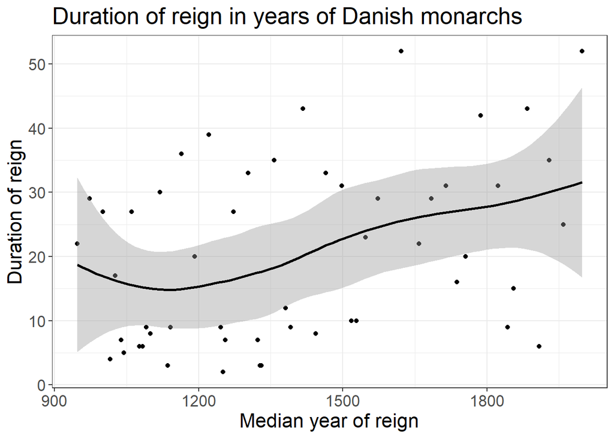

```r
# YOUR CODE
library(tidyverse)
kings_with_duration %>%
  mutate(year_mid=reign_start+(reign_end-reign_start)/2) %>%
  ggplot(aes(year_mid,reign_duration))+
  geom_point()+
  geom_smooth(colour="black")+
  labs(title = "Duration of reign in years of Danish monarchs",
       x="Median year of reign",
       y="Duration of reign")+
  theme_bw()+
  theme(text = element_text(size = 16))
```

And to submit this rmarkdown, knit it into html. But first, clean up the code chunks, adjust the date, rename the author and change the `eval=FALSE` flag to `eval=TRUE` so your script actually generates an output. Well done!